# Introducción a la estadística

author: Alejandro Cáceres date:  
autosize: true

Escuela Técnica Superior de Ingeniería de Barcelona Este  
Universitat Politècnica de Catalunya (UPC)

Capítulo 2

# Objetivo

- Definición de probabilidad
- Álgebra de probabilidad
- La probabilidad condicional

# Experimento aleatorio

Pensemos en un experimento aleatorio arquetípico: el **lanzamiento de un dado**.

- Lanzamos un dado 20 veces y obtuvimos:

1 5 1 2 2 1 2 2 3 1 1 3 3 1 6 3 5 6 4 4

- la duodécima observación tuvo el resultado de 3:

1 5 1 2 2 1 2 2 3 1 1 **3** 3 1 6 3 5 6 4 4

# Resultados de las observaciones y eventos

La tabla de frecuencias es

```
  outcome ni  fi Ni  Fi
1       1  6 0.3  6 0.3
2       2  4 0.2 10 0.5
3       3  4 0.2 14 0.7
4       4  2 0.1 16 0.8
5       5  2 0.1 18 0.9
6       6  2 0.1 20 1.0
```

- el resultado 3 se observó 4 veces:

# Resultados de las observaciones y eventos

- el evento menor o igual a 3 tuvo 14 observaciones:

$n_1+n_2+n_3=6+4+4=14$ observaciones

- el espacio muestral es

$S =\{1, 2, 3, 4, 5, 6\}$

- media:

$\bar{x}=\frac{1}{20}\sum_{j=1,..20} x_{j}=\sum_{i=1,..6}x_{i}*f_i$  
$=1*0.3+2*0.2+3*0.2+4*0.1+5*0.1+6*0.1=2.8$

$j$ enumera **observaciones**, $i$ enumera **resultados**

# Resultados de las observaciones y eventos

- mediana:

1 1 1 1 1 1 2 2 2 **2 3** 3 3 3 4 4 5 5 6 6

$mediana=2.5$

- ¿Cuál es la deviación típica?

- el experimento aleatorio es

**una** simulación por computadora del lanzamiento de un dado

- ¿Cuál es la probabiliad de obtener 3? ¿por qué?

# Experimento aleatorio

La probabiliad es una medida de la certitud de obtener un resulado en un experimento aleatorio.

- 0: totalmente cierto que el resultado no ocurre.
- 1: totalemente cierto que el resultado ocurre.

¿Como interpretamos probabilidades entre 0 y 1?

# Probabilidad

**Interpretación clásica:**

Siempre que un espacio muestral consta de N eventos posibles que son igualmente probables, la probabilidad de cada resultado es $\frac{1}{N}$.

Defendido por [Laplace (1814)](https://plato.stanford.edu/entries/probability-interpret/#ClaPro).

Cada resultado es igual de probable (declaramos completa ignarancia), lo mejor que podemos hacer es repartir equitativamente la probabilidad entre los resultados.

Para el dado tenemos la probabilidad de 1/6 de obtener cualquier resultado. La probabilidad de obtener 3 es 1/6.

¿Qué pasa cuando si **no sabemos** (no queremos suponer) que los resultados son igual de probables?

# Probabilidad

**Interpretación frecuentista:**

Interpretación frecuentista: $P(E)$ es la **frecuencia relativa** límite para el evento E cuando el número de observaciones es infinito.

Defendido por [Venn (1876)](https://plato.stanford.edu/entries/probability-interpret/#ClaPro)

La interpretación frecuentista parte de los datos (empírica) mientras que la interpretación clásica parte del razonamiento (racionalismo).

# Probabilidad

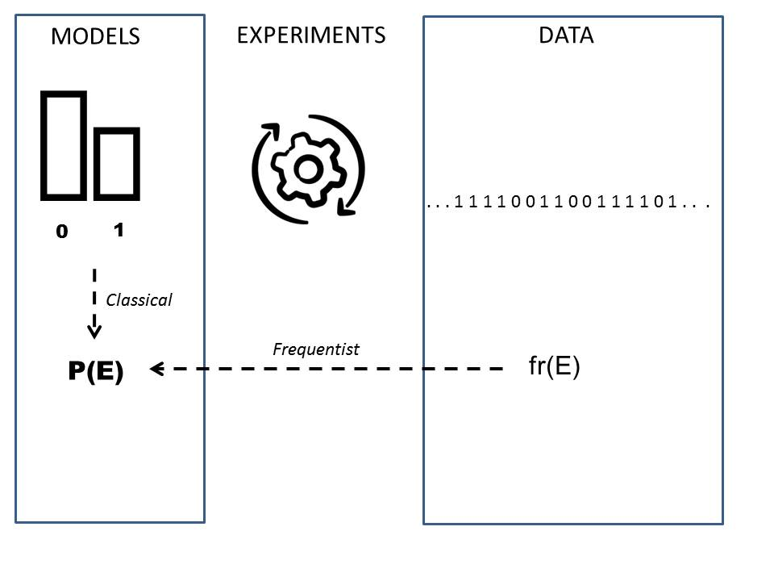

# Experimento aleatorio

- Lancemos un dado 10 veces y contemos la frecuencia de obtención de los valores posibles 1, 2, 3, 4, 5 y 6.

Contamos la proporción de veces que se observó cada valor (no observamos 2).

```
  outcome ni  fi
1       1  2 0.2
2       3  2 0.2
3       4  1 0.1
4       5  3 0.3
5       6  2 0.2
```

# Experimento aleatorio

- ¿Qué sucede cuando $N$ aumenta a 1,000?

```
  outcome  ni    fi
1       1 162 0.162
2       2 172 0.172
3       3 163 0.163
4       4 172 0.172
5       5 175 0.175
6       6 156 0.156
```

- ¿Qué sucede cuando $N \rightarrow \infty$?

# Experimento aleatorio

$$lim_{N\rightarrow \infty} f_i = P_i$$

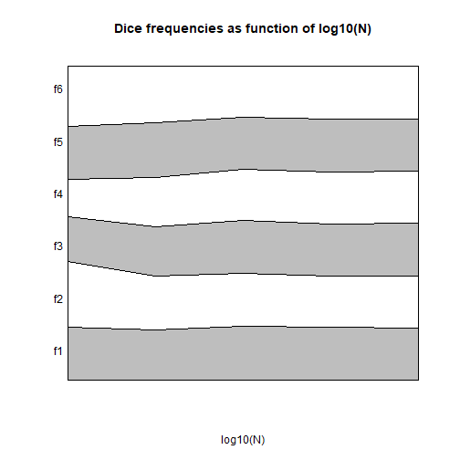

# Probabilidad

Llamamos **Probabilidad** $P_i$ al límite cuando$N \rightarrow \infty$ de la frecuencia de observación del valor $i$ en un experimento aleatorio.

- Entendemos que estos valores pertenecen a la Naturaleza, no dependen del experimentador ni del observador: describen las cosas como son.
- Como no podemos hacer un experimento infinitas veces, ¿podemos comenzar al revés? Si creemos que los $P_i$ describen las cosas como son, ¿podemos **predecir** de ellos los valores observados de $f_i$ a $N$ reales?
- ¿Cuáles son las principales propiedades lógicas de estos $P_i$?

# Espacio muestral

Comenzamos razonando cuáles son todos los valores posibles (resultados) que podría dar un experimento aleatorio.

Ten en cuenta que no tenemos que observarlos en un experimento en particular: estamos usando la **lógica** y no observación.

**Definición:**

El conjunto de todos los valores posibles que puede tomar una observación de un experimento aleatorio se denomina el **espacio muestral** del experimento. El espacio muestral se denota como $S$.

# Espacio muestral

- temperatura 35 y 42 grados centígrados
- niveles de azúcar: 70-80 mg / dL
- tamaño de un tornillo de una línea de producción: 70 mm-72 mm
- número de correos electrónicos recibidos en una hora: 0-100
- un lanzamiento de dados: 1, 2, 3, 4, 5, 6

# Espacio muestral

**Espacios muestrales discretos y continuos**

- Un espacio muestral es discreto si consta de un conjunto contable de resultados (finito o infinito).
- Un espacio muestral es continuo si consta de un intervalo de numeros reales.

# Evento

**Definición:**

Un evento es un subconjunto del espacio muestral de un experimento aleatorio. Es una colección de resultados.

# Evento

Ejemplos:

- El evento de una temperatura saludable: temperatura 37-38 grados centígrados
- El caso de producir un tornillo con tamaño: 71,5 mm
- El evento de recibir más de 4 correos electrónicos en una hora.

El evento se refiere a un conjunto de **valores** que pueden tomar los resultados.

Ten en cuenta que los resultados de diferentes experimentos pueden pertenecer al mismo evento.

# Operaciones de eventos

- La **unión** de dos eventos es el evento que consta de todos los resultados que están contenidos en cualquiera de los dos eventos. Denotamos la unión como $E1 \cup E2$.

$E1$ =hipotermia, $t <37$

$E2$ =fiebre, $t> 38$

$E1\cup E2= [35,37) \cup (38,42]$

El evento de observar a un paciente con hipotermia **O** fiebre.

# Operaciones de eventos

La **intersección** de dos eventos es el evento que consta de todos los resultados que están contenidos en ambos eventos. Denotamos la intersección como $E1 \cap E2$.

$E1$ =hipotermia, $t <37$

$E2$ =fiebre, $t> 38$

$E1\cap E2= \emptyset$

El evento de observar a un paciente con hipotermia **Y** fiebre.

# Operaciones de eventos

El **complemento** de un evento en un espacio muestral es el conjunto de resultados en el espacio muestral que no están en el evento. Denotamos el componente del evento $E$ como $E'$.

$E1$ =hipotermia, $t <37$

$E1'$ =sin hipotermina $t \geq 37$

# Operaciones de eventos

Ten en cuenta que

$E3=E1\cup E2= [35,37) \cup (38,42]$

$E3'= [37, 38]$=saludable

# diagramas de Venn

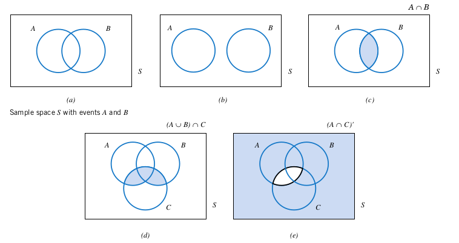

# Mutuamente excluyentes

**Definición:**

Dos eventos denotados como E1 y E2, tales que
$$E1\cap E2=\emptyset$$
se dice que son mutuamente excluyentes.

# Probabilidad

La probabilidad es una función de los eventos de $S$ que toma valores reales entre 0 y 1. Es un objeto matemático (¡no tiene nada de aleatorio!)

para $E \subseteq S$.

- 0: totalmente cierto que el evento $E$ no ocurre.
- 1: totalemente cierto que el evento $E$ ocurre.

¿Cuáles deberían ser las propiedades de $P$?

# Suma de probabilidades

Para un espacio muestral discreto pensemos que la probabilidad de un evento $E$, denotado como $P(E)$, debería igual a la suma de las probabilidades de los elementos que componen $E$.

Pensemos en el dado y descompongamos todos los eventos posibles de $E$ en los elementos que lo componen.

# Suma de probabilidades

¿Cuál es la probabilidad de lanzar un dado y obtener un número menor o igual a 3?

La certeza (probabilidad) de que 1 $o$ 2 $o$ 3 acurra debería ser la suma de las certezas.

$$P(1 \cup 2 \cup 3)=P(1)+P(2)+P(3)=1/6+1/6+1/6=1/2$$

Es claro que si $P$ es un tipo de límite de una frecuencia, entonces, como las frecuencias se pueden agregar para eventos mutuamente excluyentes ($1 \cap 2 = \emptyset$), las probabilidades también deberían poder hacerlo.

# Axiomas de probabilidad

La probabilidad es un número que se asigna a los eventos de un espacio muestral de un experimento aleatorio y que satisface las siguientes propiedades:

Si $S$ es el espacio muestral y $E$ es cualquier evento en un experimento aleatorio,

- $P(S)=1$
- $0 \leq P(E) \leq 1$
- cuando $E1\cap E2=\emptyset$
  $$P(E1\cup E2) = P(E1) + P(E2)$$

Propuesto por Kolmogorov (1933)

# Regla de suma

¿Qué ocurre cuando los eventos **no** son mutuamente excluyentes?

Los axiomas nos permiten demostrar que:

$$P(A\cup B) = P(A) + P(B) - P(A\cap B)$$

Piensa en los siguientes eventos para un dado

$A=\{1,2,3,4\}$ and $B=\{4,5\}$

entonces $P(A\cup B)$: la probabilidad de que ocurra $A$ o $B$ viene dada por  
$P(A\cup B) = [P(1)+ P(2)+P(3) +P(4)]+ [P(4)+P(5)]$  
$- P(4)=5/6$

$P(4)= P(A\cap B)$ aparece dos veces: necesitamos restar uno de ellos.

# Regla de suma

Piensa en los siguientes eventos para un dado

$A=\{1,2,3,4\}$

$B=\{4,5\}$

Ten en cuenta también que la probabilidad de que el resultado esté o no en $A\cup B$ es uno.

$$P([A\cup B]')+P([A\cup B])=1$$

Por lo tanto
$$P([A\cup B])=1-P([A\cup B]')=1-P(6)=1-1/6=5/6$$

# Ejercicio

En una avenida hay un sistema de 3 semáforos sucesivos. $R_j$ representa el suceso: encontramos en rojo el semáforo j-ésimo.

- ¿Cuál es la expresión matemática para la probabilidad de encontrar **todos** los semáforos en rojo?
- ¿Cuál es la expresión matemática para la probabilidad de encontrar **algún** semáforo en rojo?

Intentremos usar un diagrama de Venn para escribir esta probabilidad en términos de probabilidades de intersecciones, también llamadas probabilidades conjuntas.

# Ejercicio

En una avenida hay un sistema de 3 semáforos sucesivos. $R_j$ representa el suceso: encontramos en rojo el semáforo j-ésimo.

- ¿Cuál es la expresión matemática para la probabilidad de encontrar **todos** los semáforos en rojo?

$P(R_1 \cap R_2 \cap R_3 )$

- ¿Cuál es la expresión matemática para la probabilidad de encontrar **algún** semáforo en rojo?

$P(R_1\cup R_2 \cup R_3)= P(R_1) + P(R_2) + P(R_3)$  
$- P(R_2 \cap R_1) - P(R_3 \cap R_2) - P(R_3 \cap R_1)$  
$+ P(R_1\cap R_2 \cap R_3)$

# Regla de suma

Cuando tenemos tres eventos $A$, $B$ y $C$:

$P(A\cup B \cup C) = P([A\cup B] \cup C)$

$= [P(A) + P(B) - P(A\cap B)] + P(C)-P([A\cup B] \cap C)$

$= [P(A) + P(B) - P(A\cap B)] + P(C)-P([A \cap C]\cup [B \cap C])$

…

$= P(A) + P(B) + P(C) - P(A\cap B) - P(A\cap C) - P(B\cap C)$  
$+P(A\cap B \cap C)$

# Regla de suma

Para una colección de eventos mutuamente excluyentes $E1$ … $En$

$$P(E1\cup E2 .. \cup En) = P(E1)+P(E2)...+P(En)$$

Para el caso de los semáforos.

- ¿son $R_1$ y $R_2$ mutuamente excluyentes?
- ¿cuales son los eventos mutuamente excluyentes de $R_1$?

# Probabilidad conjunta

La probabilidad conjunta de dos eventos $A$ y $B$ es
$$P(A,B)=P(A \cap B)$$

Imaginemos un experimento aleatorio que mida dos tipos diferentes de resultados, resultado de tipo $A$ y resultado de tipo $B$

- altura y peso de un individuo: ($1.78m$, $75Kg$)
- posición y tiempo de una carga eléctrica: $(1\mu m, 0.05ms)$
- un lanzamiento de dos dados: ($1$, $6$)
- cruzar dos semáforos sucesivos en verde: ($\bar{R_1}$, $\bar{R_2}$)

En muchos casos, nos interesa saber si un resultado **condiciona** el otro resultado.

# Probabilidad conjunta

- si observamos que un individuo es alto es probable que también sea pesado.
- el tiempo que tarda una carga eléctrica en golpear un detector en un lugar en particular podría decirnos si atravezó un campo eléctrico.
- si observamos un número en un dado, no nos dirá cuál es el número otro dado.
- La probabilidad de pasar un semáforo en verde en gran vía aumneta la probabilidad de cruzar el siguiente en verde.

# Diagnóstico

Consideremos una herramienta de diagnóstico

Queremos encontrar el estado de un sistema:

- inadecuado (sí)
- adecuado (no)

con una prueba (t):

- positivo
- negativo

Hacemos pruebas de carga a una batería para saber su vida útil. Cargamos en un cable para saber si se resiste un determinado peso. Realizamos una PCR para ver si alguien tiene una infección.

# Probabilidad conjunta

Consideremos diagnosticar la infección con una nueva prueba.

Estado de infección:

- sí (infectado)
- no (no infectado)

Prueba:

- positivo
- negativo

# Probabilidad conjunta

Cada individuo es un experimento aleatorio con dos medidas: (Infección, Prueba)

| - sujeto - | - Infección - | - Prueba - |
| --- | --- | --- |
| $s_1$ | si | positivo |
| $s_2$ | no | negativo |
| $s_3$ | si | positivo |
| … | … | … |
| $s_i$ | no | positivo * |
| … | … | … |
| … | … | … |
| $s_n$ | si | negativo * |

# Tabla de contingencia

|  | - Infección: sí - | - Infección: no - | - suma - |
| --- | --- | --- | --- |
| - **Prueba: positiva** - | 18 | 12 | 30 |
| - **Prueba: negativa** - | 30 | 300 | 330 |
| - **suma** - | 48 | 312 | 360 |

|  | - Infección: sí - | - Infección: no - | - suma - |
| --- | --- | --- | --- |
| - **Prueba: positiva** - | $n_{pos, sí}$ | $n_ {pos, no}$ | $n_ {pos}$ |
| - **Prueba: negativa** - | $n_{neg, sí}$ | $n_ {neg, no}$ | $n_ {neg}$ |
| - **suma** - | $n_ {sí}$ | $n_{no}$ | $n$ |

# Frecuencias relativas

|  | -Infección: sí - | - Infección: no - | - suma - |
| --- | --- | --- | --- |
| - **Prueba: positiva** - | 18/360 =0,05 | 12/360 =0,0333 .. | 30/360 =0,0833 .. |
| - **Prueba: negativa** - | 30/360 =0,0833 | 300/360 =0,833 .. | 330/360 =0,9166 .. |
| - **suma** - | 48/360 =0,133 | 312/360 =0,866 .. | 1 |

|  | - Infectado: sí - | - Infectados: no - | - suma - |
| --- | --- | --- | --- |
| - **Prueba: positiva** - | $fr(positivo, sí)$ | $fr(positivo, no)$ | $fr(positivo)$ |
| - **Prueba: negativa** - | $fr(negativo, sí)$ | $fr(negativo, no)$ | $fr(negativo)$ |
| - **suma** - | $fr(sí)$ | $fr(no)$ | $1$ |

# Probabilidad conjunta

Cuando $N \rightarrow \infty$ asumimos que las frecuencias convergen a valores de probabilidad.

**Matriz de probabilidad conjunta**

|  | -Infección: sí - | - Infección: no - | - suma - |
| --- | --- | --- | --- |
| - **Prueba: positiva** - | $P(positivo, sí)$ | $P(positivo, no)$ | $P(positivo)$ |
| - **Prueba: negativa** - | $P(negativo, sí)$ | $P(negativo, no)$ | $P(negativo)$ |
| - **suma** - | $P(sí)$ | $P(no)$ | $1$ |

- $P(sí, positivo) =P (sí \cap positivo)$: probabilidad de observar $sí$ **Y** $positivo$
- $P(sí)$: Probabilidad **marginal** de observar $sí$

# La probabilidad condicional

Pensemos primero en términos de aquellos que están **infectados**

Entre los que están infectados (**sí**), ¿cuál es la frecuencia relativa con la que los individuos testados dieron positivo?

- **Sensibilidad** (tasa de verdaderos positivos)

$$fr(positivo | sí) =\frac{n_{positivo, sí}}{n_ {sí}}$$

# La probabilidad condicional

Lo escribimos en términos de frecuencias.

$$fr(positivo | sí) =\frac{n_{positivo, sí}} {n_{sí}} =\frac {\frac {n_{positivo, sí}} {n}} {\frac {n_{sí }} {n}} =\frac {fr(positivo, sí)} {fr (sí)}$$

Por lo tanto, en el límite, esperamos tener una probabilidad del tipo

$$P(positivo | sí) =\frac{P (positivo \cap sí)} {P(sí)}$$

A eso lo llamaremos probabilidad condicional de un valor **positivo** en la prueba dado un valor de **sí** en la infección.

# La probabilidad condicional

- puedes probar que la probabilidad condicional satisface los axiomas de probabilidad.
- es la probabilidad con el espacio muestral dado por $B$: $S_B$.

# La probabilidad condicional

Veamos la otra probabilidad condicional  
Dentro de los que **no** están infectados, ¿cuál es la probabilidad de que la prueba sea negativa?

- **Especificidad** (tasa de verdaderos negativos)

$$P (negativo | no) =\frac {P (negativo \cap no)} {P (no)}$$

# Matriz de diagnóstico

Matriz **condicional** sobre el valor del estado de infección.

|  | -Infección: Sí - | - Infección: No - |
| --- | --- | --- |
| - **Prueba: positiva** - | P (positivo \| sí) | P (positivo \| no) |
| - **Prueba: negativa** - | P (negativo \| sí) | P (negativo \| no) |
| - **suma** - | 1 | 1 |

- Tasa de falsos positivos: la probabilidad de dar positivo **si** no se tiene la enfermedad $P (positivo | no)$
- Tasa de falsos negativos: la probabilidad de que la prueba sea negativa **si** se tiene la enfermedad $P (negativo | sí)$

# Matriz de diagnóstico

Supongamos que las frecuencias son de $n$ suficientemente grandes para **estimar** las probabilidades

|  | -Infección: Sí - | - Infección: No - |
| --- | --- | --- |
| - **Prueba: positiva** - | 18/48 =0,375 | 12/312 =0,038 |
| - **Prueba: negativa** - | 30/48 =0,625 | 300/312 =0,962 |
| - **suma** - | 1 | 1 |

Nuestra herramienta de diagnóstico tiene baja sensibilidad (0.375) pero alta especificidad (0,962).

# Matriz de diagnóstico

En el **desarrollo** de una prueba de diagnóstico, hacemos experimentos en el laboratorio sabiendo **si** el sistema está en un estado

- inadecuado (sí)
- adecuado (no)

Bajo estas condiciones realizamos los test:

con una prueba (t):

- positivo
- negativo

Por lo tanto estamos interesados en la sensibilidad y especificidad, que son probabilidades condicionales al estado del sistema.

# Matriz de predicción

Volvamos a nuestro diagnóstico de infecciones.

Dentro de aquellos cuya prueba es positiva, ¿cuál es la probabilidad de tener la infección (sí)?

- **Valor predictivo positivo**

$$P(si|positivo)=\frac{P(si \cap positivo)}{P(positivo)}$$

# Matriz de predicción

De la misma forma podemos preguntar:

Dentro de aquellos cuya prueba es negativa, ¿cuál es la probabilidad de no tener la enfermedad (no)?

- **Valor predictivo negativo**

$$P(no|negativo)=\frac{P(no \cap negativo)}{P(negativo)}$$

# Matriz de predicción

Matriz **condicional** sobre el valor del resultado de la prueba.

|  | Infección: Sí | Infección: No | suma |
| --- | --- | --- | --- |
| **Prueba: positiva** | PPV: P (sí \| positivo) | P (no \| positivo) | 1 |
| **Prueba: negativa** | P (sí \| negativo) | VPN: P (no \| negativo) | 1 |

PPV: valor predicho positivo VPN: valor predicho negativo

¡Estos son realmente los valores que queremos saber cuando hacemos un test!

# Matriz de predicción

Supongamos que las frecuencias son de $n$ suficientemente grandes para **estimar** las probabilidades

[output not shown]

# Matriz de predicción

En el **despliegue** de una prueba de diagnóstico en una situación real realizamos los test:

con una prueba (t):

- positivo
- negativo

y **confirmamos** el estado del sistema

- inadecuado (sí)
- adecuado (no)

Por lo tanto estamos interesados en los valores **predictivos**, que son probabilidades condicionales al resultado del test.

# Ejercicio

Tenemos tres cajas (caja 1, caja 2, caja 3) en las que se almacenan condensadores de tres capacidades diferentes $(0.01\mu F, 0.1 \mu F, 1.0\mu F)$, como se muestra en el cuadro siguiente:

| $\mu$ F | box 1 | box 2 | box 3 | Total |
| --- | --- | --- | --- | --- |
| 0.01 | 20 | 95 | 25 | 140 |
| 0.1 | 55 | 35 | 75 | 165 |
| 1.0 | 70 | 80 | 145 | 295 |
| Total | 145 | 210 | 245 | 600 |

Deﬁnimos $0.01\mu F$, $0.1\mu F$ y $1.0\mu F$ como los sucesos de extraer un condensador de $0.01\mu F$, $0.1\mu F$ y $1.0\mu F$, respectivamente. De igual forma, deﬁnimos $c1$, $c2$ y $c3$ a los sucesos de elegir la caja 1, la caja 2 y la caja 3, respectivamente. Escogemos al azar una caja y de ella, a su vez, un condensador. Se pide:

- ¿Cuál es la probabilidad de seleccionar la caja 2 **y** un condensador de $0.1\mu F$?

Pistas:

- ¿Cuál es la probabilidad de escojer la caja 2?
- Obten la matriz condicional sobre el valor de cada caja.
- Escribe la probabilidad conjunta que necesitas en términos de una de las probabilidades condicionales del paso anterior.